# hw333

2022-04-19

## Classification

For this assignment, we will be working with part of a [Kaggle data set](https://www.kaggle.com/c/titanic/overview) that was the subject of a machine learning competition and is often used for practicing ML models. The goal is classification; specifically, to predict which passengers would survive the [Titanic shipwreck](https://en.wikipedia.org/wiki/Titanic).

Load the data from `data/titanic.csv` into *R* and familiarize yourself with the variables it contains using the codebook (`data/titanic_codebook.txt`).

```r
setwd("C:/Users/82107/Documents/myrepo/hw3333/HOMEWORK3")

data <-read.csv(file="titanic.csv",stringsAsFactors = FALSE,header = TRUE)
```

Notice that `survived` and `pclass` should be changed to factors. When changing `survived` to a factor, you may want to reorder the factor so that *“Yes”* is the first level.

```r
data$survived <- as.factor(data$survived)
data$pclass <- as.factor(data$pclass)
data$survived <- factor(data$survived, levels = c('Yes', 'No'))
```

Make sure you load the `tidyverse` and `tidymodels`!

```r
library(tidyverse)
library(tidymodels)
```

*Remember that you’ll need to set a seed at the beginning of the document to reproduce your results.*

```r
set.seed(1234)
```

### Question 1

Split the data, stratifying on the outcome variable, `survived.` You should choose the proportions to split the data into. Verify that the training and testing data sets have the appropriate number of observations. Take a look at the training data and note any potential issues, such as missing data.

```r
titanic_split <- initial_split(data, prop = 0.8, strata = survived)
titanic_train <- training(titanic_split)
titanic_test <- testing(titanic_split)
```

```r
# Verify that the training and testing data sets have the appropriate number of observations
nrow(titanic_train) # 712
```

```
## [1] 712
```

```r
nrow(titanic_test) # 179
```

```
## [1] 179
```

```r
# Take a look at the training data and note any potential issues, such as missing data.
x <- length(names(titanic_train))
y <- cbind(names(titanic_train),1:x)
for(i in 1:x){
  y[i,2] <- sum(is.na(titanic_train[,i]))
}
y
```

```
##       [,1]           [,2]
##  [1,] "passenger_id" "0"
##  [2,] "survived"     "0"
##  [3,] "pclass"       "0"
##  [4,] "name"         "0"
##  [5,] "sex"          "0"
##  [6,] "age"          "136"
##  [7,] "sib_sp"       "0"
##  [8,] "parch"        "0"
##  [9,] "ticket"       "0"
## [10,] "fare"         "0"
## [11,] "cabin"        "552"
## [12,] "embarked"     "2"
```

```r
table(is.na(titanic_train$age))
```

```
##
## FALSE  TRUE
##   576   136
```

```r
table(is.na(titanic_train$cabin))
```

```
##
## FALSE  TRUE
##   160   552
```

```r
table(is.na(titanic_train$embarked))
```

```
##
## FALSE  TRUE
##   710     2
```

Why is it a good idea to use stratified sampling for this data?

```r
# It is a good idea to use stratified sampling for this data, because the proportion of missing values is still same.
```

### Question 2

Using the **training** data set, explore/describe the distribution of the outcome variable `survived`.

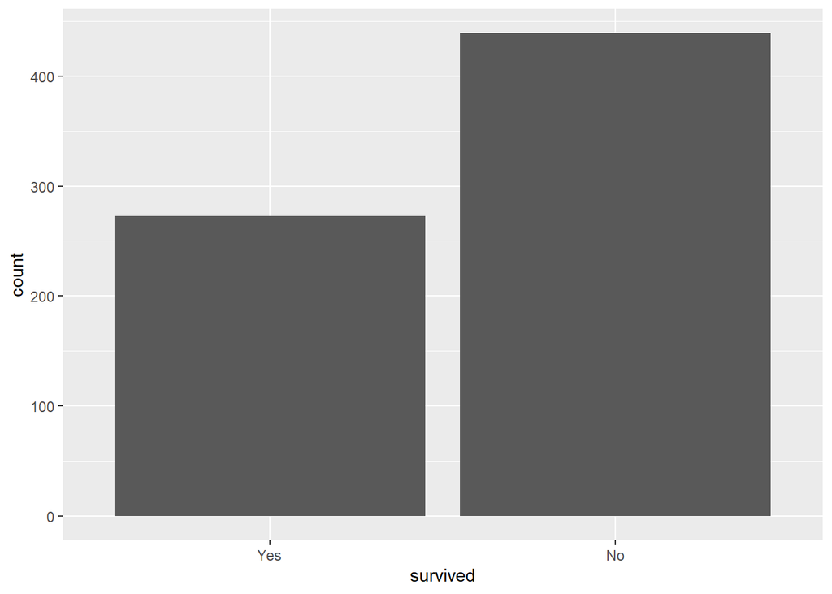

```r
titanic_train %>%
  ggplot(aes(x = survived)) +
  geom_bar()
```

### Question 3

Using the **training** data set, create a correlation matrix of all continuous variables. Create a visualization of the matrix, and describe any patterns you see. Are any predictors correlated with each other? Which ones, and in which direction?

```r
library(corrr)
cor_train <- titanic_train %>%
  select(is.numeric) %>%
  correlate()
```

```
##
## Correlation method: 'pearson'
## Missing treated using: 'pairwise.complete.obs'
```

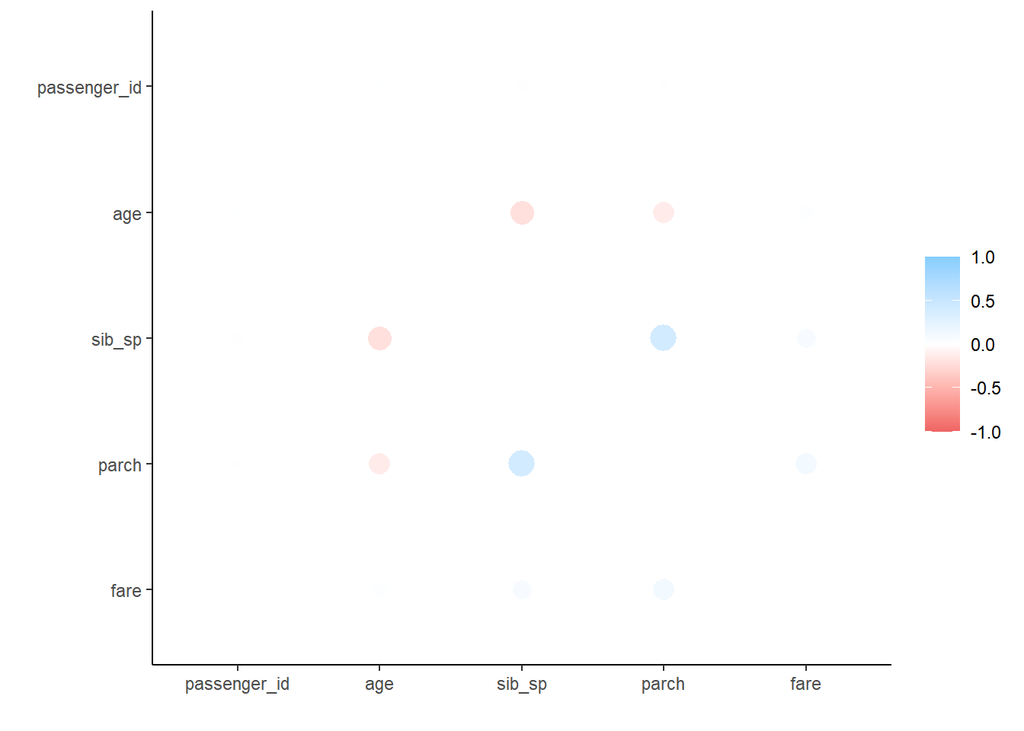

```r
rplot(cor_train)
```

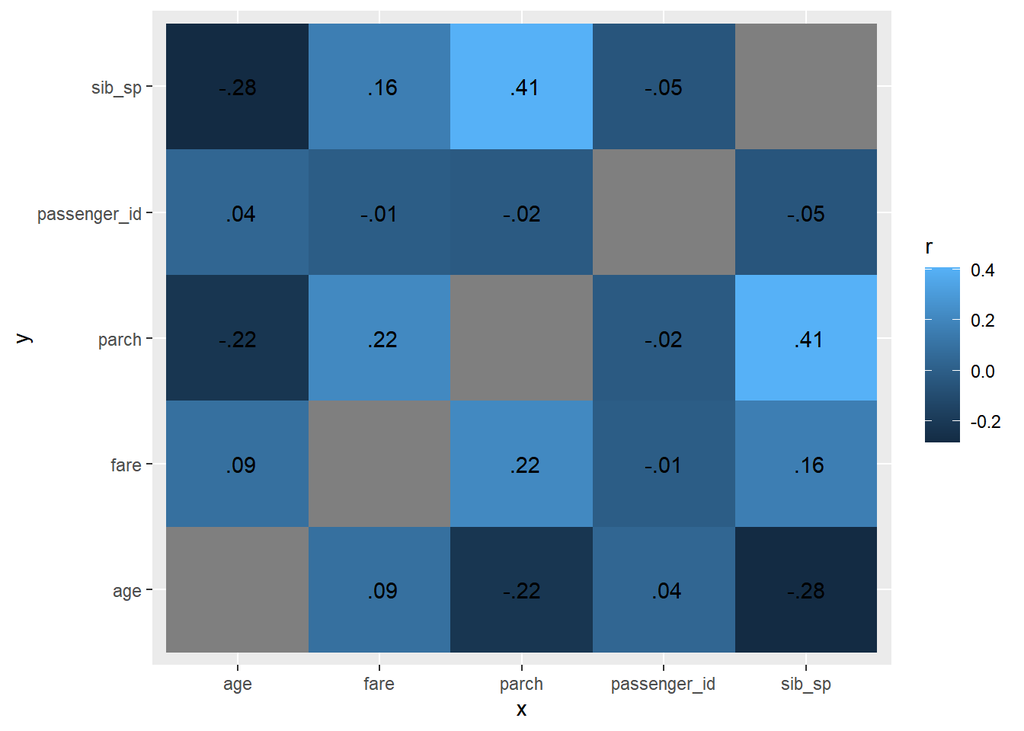

```r
cor_train %>%
  stretch() %>%
  ggplot(aes(x, y, fill = r)) +
  geom_tile() +
  geom_text(aes(label = as.character(fashion(r))))
```

```r
# Describe any patterns you see. Are any predictors correlated with each other? Which ones, and in which direction?
# 'parch' and 'sib_sp' are correlated with each other, in positive direction.
# 'age' and 'sib_sp' are correlated with each other, in negative direction.
```

### Question 4

Using the **training** data, create a recipe predicting the outcome variable `survived`. Include the following predictors: ticket class, sex, age, number of siblings or spouses aboard, number of parents or children aboard, and passenger fare.

```r
titanic_recipe <- recipe(survived ~ pclass + sex + age + sib_sp +
                           parch + fare, data = titanic_train) %>%
  step_impute_linear(age) %>%
  step_dummy(all_nominal_predictors()) %>%
  step_interact(terms = ~starts_with("sex"):fare+age:fare)

titanic_recipe
```

```
## Recipe
##
## Inputs:
##
##       role #variables
##    outcome          1
##  predictor          6
##
## Operations:
##
## Linear regression imputation for age
## Dummy variables from all_nominal_predictors()
## Interactions with starts_with("sex"):fare + age:fare
```

Recall that there were missing values for `age`. To deal with this, add an imputation step using `step_impute_linear()`. Next, use `step_dummy()` to **dummy** encode categorical predictors. Finally, include interactions between:

- Sex and passenger fare, and
- Age and passenger fare.

You’ll need to investigate the `tidymodels` documentation to find the appropriate step functions to use.

### Question 5

Specify a **logistic regression** model for classification using the `"glm"` engine. Then create a workflow. Add your model and the appropriate recipe. Finally, use `fit()` to apply your workflow to the **training** data.

*Hint: Make sure to store the results of `fit()`. You’ll need them later on.*

```r
log_reg <- logistic_reg() %>%
  set_engine("glm") %>%
  set_mode("classification")


lr_wkflow <- workflow() %>%
  add_model(log_reg) %>%
  add_recipe(titanic_recipe)

lr_fit<- fit(lr_wkflow,titanic_train)

lr_fit %>%
  tidy()
```

```
## # A tibble: 10 x 5
##    term             estimate std.error statistic  p.value
##    <chr>               <dbl>     <dbl>     <dbl>    <dbl>
##  1 (Intercept)     -4.22      0.640      -6.59   4.51e-11
##  2 age              0.0520    0.0120      4.33   1.51e- 5
##  3 sib_sp           0.477     0.124       3.84   1.23e- 4
##  4 parch           -0.0101    0.137      -0.0739 9.41e- 1
##  5 fare            -0.00544   0.0106     -0.511  6.09e- 1
##  6 pclass_X2        1.28      0.350       3.67   2.42e- 4
##  7 pclass_X3        2.47      0.368       6.71   1.90e-11
##  8 sex_male         2.47      0.300       8.26   1.48e-16
##  9 sex_male_x_fare  0.0130    0.00843     1.55   1.22e- 1
## 10 fare_x_age      -0.000206  0.000189   -1.09   2.76e- 1
```

### Question 6

**Repeat Question 5**, but this time specify a linear discriminant analysis model for classification using the `"MASS"` engine.

```r
library(discrim)
lda_mod <- discrim_linear() %>%
  set_engine("MASS") %>%
  set_mode("classification")

lda_wkflow <- workflow() %>%
  add_model(lda_mod) %>%
  add_recipe(titanic_recipe)

lda_fit<- fit(lda_wkflow,titanic_train)
```

### Question 7

**Repeat Question 5**, but this time specify a quadratic discriminant analysis model for classification using the `"MASS"` engine.

```r
qda_mod <- discrim_quad() %>%
  set_engine("MASS") %>%
  set_mode("classification")


qda_wkflow <- workflow() %>%
  add_model(qda_mod) %>%
  add_recipe(titanic_recipe)

qda_fit<- fit(qda_wkflow,titanic_train)
```

### Question 8

**Repeat Question 5**, but this time specify a naive Bayes model for classification using the `"klaR"` engine. Set the `usekernel` argument to `FALSE`.

```r
library(klaR)
library(ISLR)
library(ISLR2)
library(poissonreg)
tidymodels_prefer()

nb_mod <- naive_Bayes() %>%
  set_mode("classification") %>%
  set_engine("klaR") %>%
  set_args(usekernel = FALSE)


nb_wkflow <- workflow() %>%
  add_model(nb_mod) %>%
  add_recipe(titanic_recipe)

nb_fit<- fit(nb_wkflow,titanic_train)
```

### Question 9

Now you’ve fit four different models to your training data.

Use `predict()` and `bind_cols()` to generate predictions using each of these 4 models and your **training** data. Then use the *accuracy* metric to assess the performance of each of the four models.

Which model achieved the highest accuracy on the training data?

```r
p1 <- predict(lr_fit, new_data = titanic_train, type = "prob")
p2 <- predict(lda_fit, new_data = titanic_train, type = "prob")
p3 <- predict(qda_fit, new_data = titanic_train, type = "prob")
p4 <- predict(nb_fit, new_data = titanic_train, type = "prob")
pred1 <- bind_cols(p1, titanic_train)

pred2 <- bind_cols(p2, titanic_train)

pred3 <- bind_cols(p3, titanic_train)

pred4 <- bind_cols(p4, titanic_train)


lr_ac <- augment(lr_fit, new_data = titanic_train) %>%
  accuracy(truth = survived, estimate = .pred_class)
lr_ac
```

```
## # A tibble: 1 x 3
##   .metric  .estimator .estimate
##   <chr>    <chr>          <dbl>
## 1 accuracy binary         0.819
```

```r
lda_ac <- augment(lda_fit, new_data = titanic_train) %>%
  accuracy(truth = survived, estimate = .pred_class)
lda_ac
```

```
## # A tibble: 1 x 3
##   .metric  .estimator .estimate
##   <chr>    <chr>          <dbl>
## 1 accuracy binary         0.803
```

```r
qda_ac <- augment(qda_fit, new_data = titanic_train) %>%
  accuracy(truth = survived, estimate = .pred_class)
qda_ac
```

```
## # A tibble: 1 x 3
##   .metric  .estimator .estimate
##   <chr>    <chr>          <dbl>
## 1 accuracy binary         0.789
```

```r
nb_ac <- augment(nb_fit, new_data = titanic_train) %>%
  accuracy(truth = survived, estimate = .pred_class)
nb_ac
```

```
## # A tibble: 1 x 3
##   .metric  .estimator .estimate
##   <chr>    <chr>          <dbl>
## 1 accuracy binary         0.784
```

```r
accuracies <- c(lr_ac$.estimate, lda_ac$.estimate,
                qda_ac$.estimate, nb_ac$.estimate)
models <- c("Logistic Regression", "LDA", "QDA", "Naive Bayes")
results <- tibble(accuracies = accuracies, models = models)
results %>%
  arrange(-accuracies)
```

```
## # A tibble: 4 x 2
##   accuracies models
##        <dbl> <chr>
## 1      0.819 Logistic Regression
## 2      0.803 LDA
## 3      0.789 QDA
## 4      0.784 Naive Bayes
```

```r
# Which model achieved the highest accuracy on the training data?
# Logistic Regression model achieved the highest accuracy on the training data.
```